# MY472 - Assignment 3

In this assignment, we will use Wikipedia as a training ground to study web scraping. There also exists a Wikidata API which can be more convenient for certain projects later, however, as the purpose of this assignment is to study web scraping, **do not use this or other APIs here**. Also please make sure to avoid sending too many requests to the website too quickly by adding some short pauses into the code.

When knitting your final markdown file, ensure that the code in Exercises 1-3 actually scrapes all information again. In other words, do not load data from files in interim steps where it is unclear how these files were created. Graders would need to see from the code that it scraped all information when it actually ran/was knitted.

```r
suppressMessages(library("tidyverse"))
suppressMessages(library("rvest"))
suppressMessages(library("quanteda"))
```

```r
suppressMessages(library("quanteda.textplots"))
suppressMessages(library("dplyr"))
suppressMessages(library("colorspace"))
```

## Exercise 1 (12 points)

Scrape the table with the 50 highest grossing films from https://en.wikipedia.org/wiki/List_of_highest-grossing_films, process the data, and store it in a data frame/tibble. Then use `ggplot2` to plot the data with the log rank on the x-axis, log world-wide gross on the y-axis, and points being annotated by movie titles. In the plot, do you see a pattern familiar from the lecture?

```r
# Your code here
url <- "https://en.wikipedia.org/wiki/List_of_highest-grossing_films"

# Storing the url's HTML code
html_content <- read_html(url)

# Extracting tables in the document
film_tab <- html_table(html_content, fill = TRUE)

# Save the dataframe (tibble)
film_tp_data <- film_tab[[1]]
film_data <- as_tibble(film_tp_data)


# Remove commas and then make variable numeric
film_data$`Worldwide gross` <-  gsub(",", "", film_data$`Worldwide gross` )
film_data$`Worldwide gross` <-  as.numeric(gsub("\\$", "", film_data$`Worldwide gross` ))
film_data
```

```
## # A tibble: 50 × 6
##     Rank Peak  Title                        `Worldwide gross`  Year Reference(…¹
##    <int> <chr> <chr>                                    <dbl> <int> <chr>
##  1     1 1     Avatar                              2922917914  2009 [# 1][# 2]
##  2     2 1     Avengers: Endgame                   2797501328  2019 [# 3][# 4]
##  3     3 1     Titanic                             2187535296  1997 [# 5][# 6]
##  4     4 3     Star Wars: The Force Awakens        2068223624  2015 [# 7][# 8]
##  5     5 4     Avengers: Infinity War              2048359754  2018 [# 9][# 10]
##  6     6 6     Spider-Man: No Way Home             1916306995  2021 [# 11][# 12]
##  7     7 3     Jurassic World                      1671537444  2015 [# 13][# 14]
##  8     8 7     The Lion King                       1656943394  2019 [# 15][# 4]
##  9     9 3     The Avengers                        1518812988  2012 [# 16][# 17]
## 10    10 4     Furious 7                           1516045911  2015 [# 18][# 19]
## # … with 40 more rows, and abbreviated variable name ¹`Reference(s)`
```

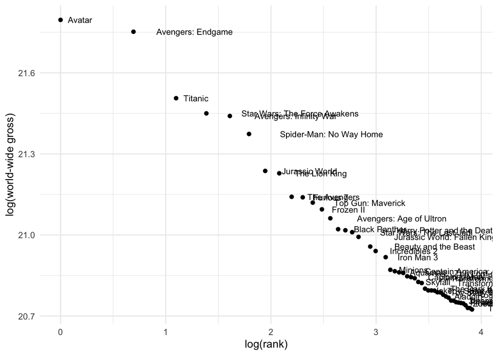

```r
# Creating the plot
ggplot(film_data) +
  aes(x = log(Rank), y = log(`Worldwide gross`),label = Title) +
  geom_point() +
  scale_x_continuous("log(rank)") +
  scale_y_continuous("log(world-wide gross)",labels=scales::comma) +
  geom_text(hjust=-0.3, size=3)+
  theme_minimal()
```

## Exercise 2 (28 points)

This exercise discusses three different approaches which are very helpful to know when scraping websites. The exemplary website we will look at is a simplified version of a recent LSE course list. You can find the website under the following link https://lse-my472.github.io/week05/data/lse_courses.html

In each of Parts 2.1-2.3, using `rvest`, the goal is to scrape all course titles and store them in a character vector with one element being one course title.

The first elements of such a vector should therefore be:

“AC411 Accounting, Strategy and Control”, “AC412 Accountability, Organisations and Risk Management”, “AC415 Management Accounting for Decision Making”, “AC416 Topics in Financial Reporting”, …

### 2.1 Approach one: Scraping all elements with one CSS selector

Inspect the website’s source code in your browser to see which CSS selector would be able to select all course titles in one go. As a hint, have a think which HTML tag specifies the desired parts of the website and what its corresponding CSS selector is. Inserting this CSS selector into `html_elements()` will allow to scrape all course titles with one line of code. There is no need to copy the CSS selector with your browser or run a loop in this part of the exercise.

Print out the length of the final character vector storing all course titles (i.e. to show how many course titles were scraped) and also print out the first 20 elements/course titles.

```r
# Your code here
url <- "https://lse-my472.github.io/week05/data/lse_courses.html"

# Storing the url's HTML code
html_course <- read_html(url)

# Recall that the CSS selector of a paragraph was "tr"
course_title <- html_elements(html_course, css = "tr") %>%
  html_text() %>%
  str_remove_all("\\n\\n?[A-Z]*\\n") %>%
  str_subset( "\\S")

# print out the first 20 course titles
paste("Total course titles:", length (course_title))
```

```
## [1] "Total course titles: 1113"
```

```r
print("The first 20 titles:")
```

```
## [1] "The first 20 titles:"
```

```r
course_title[1:20]
```

```
##  [1] "AC411 Accounting, Strategy and Control "
##  [2] "AC412 Accountability, Organisations and Risk Management "
##  [3] "AC415 Management Accounting for Decision Making "
##  [4] "AC416 Topics in Financial Reporting "
##  [5] "AC417 Corporate Financial Disclosure and Investor Relations "
##  [6] "AC424 Accounting, Organisations and Institutions "
##  [7] "AC425 MSc Accounting, Organisations and Institutions: Pre-sessional course "
##  [8] "AC444 Valuation and Security Analysis "
##  [9] "AC470 Accounting in the Global Economy "
## [10] "AC480 Quantitative Methods in Accounting and Finance "
## [11] "AC490 Management Accounting, Decisions and Control "
## [12] "AC491 Financial Accounting, Reporting and Disclosure "
## [13] "AC493 Financial and Management Accounting for Managerial Decision Making "
## [14] "AC499 Dissertation "
## [15] "AN402 The Anthropology of Religion "
## [16] "AN404 Anthropology: Theory and Ethnography "
## [17] "AN405 The Anthropology of Kinship, Sex and Gender "
## [18] "AN419 The Anthropology of Christianity "
## [19] "AN420 The Anthropology of Southeast Asia "
## [20] "AN424 The Anthropology of Melanesia "
```

### 2.2 Approach two: Loops to scrape element by element

When it is not easily possible to define a unifying CSS selector, another approach is copying element-specific CSS selectors with your browser, understanding their structure, and then building a loop (you can of course also copy the element-specific XPath instead of the CSS selector if you attempt the exercise after we have discussed XPaths in week 7). One usually copies and looks at selectors for a few elements until a pattern emerges that can be used in the loop. I have copied the CSS selectors obtained through Firefox of a few course titles in the first and second department and added them below.

First department (AC):

`body > div:nth-child(1) > table:nth-child(1) > tbody:nth-child(1) > tr:nth-child(2) > td:nth-child(1) > p:nth-child(1)` `body > div:nth-child(1) > table:nth-child(1) > tbody:nth-child(1) > tr:nth-child(3) > td:nth-child(1) > p:nth-child(1)` `body > div:nth-child(1) > table:nth-child(1) > tbody:nth-child(1) > tr:nth-child(4) > td:nth-child(1) > p:nth-child(1)` `...`

Second department (AN):

`body > div:nth-child(1) > table:nth-child(2) > tbody:nth-child(1) > tr:nth-child(2) > td:nth-child(1) > p:nth-child(1)` `body > div:nth-child(1) > table:nth-child(2) > tbody:nth-child(1) > tr:nth-child(3) > td:nth-child(1) > p:nth-child(1)` `...`

Create a double for-loop to iterate over all departments and course titles. At each iteration of the loop, use the `sprintf` function to create the correct CSS selector or XPath as a string. Then use this string to scrape the respective course title and add it to a vector that stores all course titles.

At the end, print out the length of the final character vector storing all course titles (i.e. to show how many course titles were scraped) and also print out the first 20 elements/course titles.

Hint 1: Have a look at the following code sample to see how `sprintf` can be used to change a string at each iteration of loops. The placeholders `%g` are replaced with the values of `a` and `b`.

```r
# Scrape the head of the department name

target_text_output <- c()

for (a in 1:length(html_elements(html_course, css = "h3"))) {
  # Select the html for each department
  class_string <- sprintf("body > div:nth-child(1) > table:nth-child(%g)", a)
  # Obtain the numbers of the courses of different departments
  course_html <- html_elements(html_course, css = class_string)
  for (b in 2:length(html_elements(course_html, css = "p"))) {
    some_string <- sprintf("body > div:nth-child(1) > table:nth-child(%g) > tbody:nth-child(1) > tr:nth-child(%g) > td:nth-child(1)", a, b)
    target_text <- html_elements(html_course,some_string) %>%
      html_text()
    # Append the courese title to the vector
    target_text_output <- append(target_text_output,target_text)
  }
}

# print out the first 20 course titles
paste("Total course titles:", length (target_text_output))
```

```
## [1] "Total course titles: 1089"
```

```r
print("The first 20 titles:")
```

```
## [1] "The first 20 titles:"
```

```r
target_text_output[1:20]
```

```
##  [1] "AC411 Accounting, Strategy and Control"
##  [2] "AC412 Accountability, Organisations and Risk Management"
##  [3] "AC415 Management Accounting for Decision Making"
##  [4] "AC416 Topics in Financial Reporting"
##  [5] "AC417 Corporate Financial Disclosure and Investor Relations"
##  [6] "AC424 Accounting, Organisations and Institutions"
##  [7] "AC425 MSc Accounting, Organisations and Institutions: Pre-sessional course"
##  [8] "AC444 Valuation and Security Analysis"
##  [9] "AC470 Accounting in the Global Economy"
## [10] "AC480 Quantitative Methods in Accounting and Finance"
## [11] "AC490 Management Accounting, Decisions and Control"
## [12] "AC491 Financial Accounting, Reporting and Disclosure"
## [13] "AC493 Financial and Management Accounting for Managerial Decision Making"
## [14] "AN402 The Anthropology of Religion"
## [15] "AN404 Anthropology: Theory and Ethnography"
## [16] "AN405 The Anthropology of Kinship, Sex and Gender"
## [17] "AN419 The Anthropology of Christianity"
## [18] "AN420 The Anthropology of Southeast Asia"
## [19] "AN424 The Anthropology of Melanesia"
## [20] "AN436 The Anthropology of Development"
```

Hint 2: One challenge is that each department has varying numbers of courses. One way is to choose a high number of iterations for the inner loop over course names in a department and to make sure the code keeps running even if respective CSS selectors or XPaths were not found for a given department-course observation, i.e. if that department offered fewer courses. In `rvest`, functions like `html_elements()` conveniently do not return an error if no element associated with a CSS selector or XPath was found but instead return a list of length zero and thereby allow the code to keep running.

```r
# Your code here

target_text_output2 <- c()

# Select the courses, and I tried many numbers, the 150 seems to be the most suitable for courses of different departments
for (a in 1:length(html_elements(html_course, css = "h3"))) {
  for (b in 2:150) {
    some_string2 <- sprintf("body > div:nth-child(1) > table:nth-child(%g) > tbody:nth-child(1) > tr:nth-child(%g) > td:nth-child(1)", a, b)
    target_text2 <- html_elements(html_course,some_string2) %>%
      html_text()
    # break when return a list of length zero
    if (length(target_text2) == 0){
      break
    }
    target_text_output2 <- append(target_text_output2, target_text2)
  }
}

paste("Total course titles:", length (target_text_output2))
```

```
## [1] "Total course titles: 1113"
```

```r
print("The first 20 titles:")
```

```
## [1] "The first 20 titles:"
```

```r
target_text_output2[1:20]
```

```
##  [1] "AC411 Accounting, Strategy and Control"
##  [2] "AC412 Accountability, Organisations and Risk Management"
##  [3] "AC415 Management Accounting for Decision Making"
##  [4] "AC416 Topics in Financial Reporting"
##  [5] "AC417 Corporate Financial Disclosure and Investor Relations"
##  [6] "AC424 Accounting, Organisations and Institutions"
##  [7] "AC425 MSc Accounting, Organisations and Institutions: Pre-sessional course"
##  [8] "AC444 Valuation and Security Analysis"
##  [9] "AC470 Accounting in the Global Economy"
## [10] "AC480 Quantitative Methods in Accounting and Finance"
## [11] "AC490 Management Accounting, Decisions and Control"
## [12] "AC491 Financial Accounting, Reporting and Disclosure"
## [13] "AC493 Financial and Management Accounting for Managerial Decision Making"
## [14] "AC499 Dissertation"
## [15] "AN402 The Anthropology of Religion"
## [16] "AN404 Anthropology: Theory and Ethnography"
## [17] "AN405 The Anthropology of Kinship, Sex and Gender"
## [18] "AN419 The Anthropology of Christianity"
## [19] "AN420 The Anthropology of Southeast Asia"
## [20] "AN424 The Anthropology of Melanesia"
```

### 2.3 Approach three: Scrape content directly from the full HTLM text with regular expressions

A third approach can sometimes be to use no selectors at all, but rather define a regular expression which captures all relevant information directly from the page’s full HTML text. The goal here is to define a regular expression which captures all course codes and to use this expression with the parsed HTML text in R.

Hint: You can just use `str_extract_all()` with the object `page_html_text` as input and a suitable regular expression to collect all course titles into a character vector (i.e. do not use any further `rvest` code here other than the line already added to the code chunk). Then print out the length of the final character vector storing all course titles (i.e. to show how many course titles were scraped) and also print out the first 20 elements/course titles.

```r
page_html_text <- read_html("https://lse-my472.github.io/week05/data/lse_courses.html") %>% html_text()
# Your code here

course_titles_all <- str_extract_all(page_html_text, "[A-Z]{2}[A-Z|0-9]{3}.+?(?= (\n|[A-Z]{2}))")
paste("Total course titles:", length(course_titles_all[[1]]))
```

```
## [1] "Total course titles: 1113"
```

```r
print("The first 20 titles:")
```

```
## [1] "The first 20 titles:"
```

```r
for (i in 1:20){
  print(course_titles_all[[1]][[i]])
}
```

```
## [1] "AC411 Accounting, Strategy and Control"
## [1] "AC412 Accountability, Organisations and Risk Management"
## [1] "AC415 Management Accounting for Decision Making"
## [1] "AC416 Topics in Financial Reporting"
## [1] "AC417 Corporate Financial Disclosure and Investor Relations"
## [1] "AC424 Accounting, Organisations and Institutions"
## [1] "AC425 MSc Accounting, Organisations and Institutions: Pre-sessional course"
## [1] "AC444 Valuation and Security Analysis"
## [1] "AC470 Accounting in the Global Economy"
## [1] "AC480 Quantitative Methods in Accounting and Finance"
## [1] "AC490 Management Accounting, Decisions and Control"
## [1] "AC491 Financial Accounting, Reporting and Disclosure"
## [1] "AC493 Financial and Management Accounting for Managerial Decision Making"
## [1] "AC499 Dissertation"
## [1] "AN402 The Anthropology of Religion"
## [1] "AN404 Anthropology: Theory and Ethnography"
## [1] "AN405 The Anthropology of Kinship, Sex and Gender"
## [1] "AN419 The Anthropology of Christianity"
## [1] "AN420 The Anthropology of Southeast Asia"
## [1] "AN424 The Anthropology of Melanesia"
```

```r
#I learned the "()","?="in a chinese website: https://www.runoob.com/regexp/regexp-syntax.html
#This is the English one for "()"：https://stackoverflow.com/questions/3789417/whats-the-difference-between-and-in-regular-expression-patterns
#This is the English one for "?=": https://stackoverflow.com/questions/1570896/what-does-mean-in-a-regular-expression
```

## Exercise 3 (60 points)

This is an open-ended exercise that allows you to study web scraping using the English Wikipedia https://en.wikipedia.org/ while collecting and analysing information that you are particularly interested in. It could e.g. be about historical events, politics, science, arts, sports, economics, etc.

3.1 Write code which scrapes all information from Wikipedia that you would like to analyse and illustrate.

3.2 Clean all data and store it in one or more data frames/tibbles/quanteda objects etc.

3.3 Illustrate your findings. This could e.g. be a combination of computations with packages such as `dplyr`, text analysis with `quanteda`, visualisations with packages such as `ggplot2` or `plotly` or others, and/or written answers.

More extensive, carefully thought out, polished, and well understandable answers will receive more points. For general assessment criteria, also see the course website https://lse-my472.github.io/

Hint: Should you decide to use text analysis with `quanteda` as part of your project (note: there are many ways to answer this exercise and using `quanteda` is not necessary and only one option), a question might be how to load most of the text of Wikipedia articles into character vectors such that it can then be transformed into a `dfm` for applying dictionaries, analysing word shares, etc. One quick approximate approach is illustrated below. It combines all paragraphs of a respective Wikipedia page (this leaves out e.g. lists but often captures most of the textual information).

```r
sample_page <- "https://en.wikipedia.org/wiki/Claude_Shannon"

html_sample_page <- read_html(sample_page)

main_text_content <- html_sample_page %>% html_elements(css = "p") %>% html_text() %>% paste(collapse = " ")
```

As a side note, Shannon was one of the most important researchers of the 20th century and his ideas are the foundation of much of the information age, but he remains relatively unknown. If you have not heard of his research and are interested in learning more, e.g. have a look at this [trailer](https://youtu.be/E3OldEtfBrE) or his Wikipedia page.

Lastly, information on the Wikipedia website can be edited at any time. If it happens that your chosen article/s is/are subject to regular edits that could change the content/structure of the page (and possibly break your code) you may want to use the permanent link to a particular revision of your article. To get this link for an article, click ‘View history’ (top right), then the top entry for the time & date. This is not essential, but will ensure your code is reproducible when being graded.

```r
# Your code here

##3.1 scrapes all information from Wikipedia used to analyse

#scrab the list of best-selling fiction authors in Wikipedia
url <- "https://en.wikipedia.org/w/index.php?title=List_of_best-selling_fiction_authors&oldid=1121187063"

# Storing the url's HTML code
html_content <- read_html(url)
# Extracting tables in the document
fiction_tab <- html_table(html_content, fill = TRUE)


# Save the dataframe (tibble)
fiction_tp_data <- fiction_tab[[1]]
fiction_data <- as_tibble(fiction_tp_data)

##3.2 Clean all data
# Remove useless things and then make variable numeric
fiction_data$`Min. estimated sales` <-  gsub("billion", "000", fiction_data$`Min. estimated sales`)
fiction_data$`Min. estimated sales` <- gsub("million", "", fiction_data$`Min. estimated sales` )
fiction_data$`Min. estimated sales` <- gsub("\\[[0-9]*\\]", "", fiction_data$`Min. estimated sales` )
fiction_data$`Min. estimated sales` <- as.numeric(gsub("\\s", "", fiction_data$`Min. estimated sales`))
fiction_data$`Max. estimated sales` <-  gsub("billion", "000", fiction_data$`Max. estimated sales`)
fiction_data$`Max. estimated sales` <-  gsub("million", "", fiction_data$`Max. estimated sales`)
fiction_data$`Max. estimated sales` <- gsub("\\[[0-9]*\\]", "", fiction_data$`Max. estimated sales` )
fiction_data$`Max. estimated sales` <-  as.numeric(gsub("\\s", "", fiction_data$`Max. estimated sales`))
fiction_data$`Number of books` <- gsub("\\[[0-9]*\\]", "", fiction_data$`Number of books` )
fiction_data$`Number of books` <-  as.numeric(gsub("\\s", "", fiction_data$`Number of books`))
fiction_data$`Genre and/or major works` <- gsub(",.+","", fiction_data$`Genre and/or major works`)

# rename the rows,because the numbers are calculated as million now
fiction_data_tp <- rename(fiction_data,"Max-estimated_sales(Million)" = `Max. estimated sales`)%>%
  rename("Min-estimated_sales(Million)" = `Min. estimated sales`) %>%
  mutate(Mean_estimated_sales = (fiction_data$`Min. estimated sales`+fiction_data$`Max. estimated sales`)/2, na.rm = TRUE)

fiction_data_tp
```

```
## # A tibble: 100 × 9
##    Author          Min-e…¹ Max-e…² Origi…³ Genre…⁴ Numbe…⁵ Natio…⁶ Mean_…⁷ na.rm
##    <chr>             <dbl>   <dbl> <chr>   <chr>     <dbl> <chr>     <dbl> <lgl>
##  1 William Shakes…    2000    4000 English Plays …      42 English    3000 TRUE
##  2 Agatha Christie    2000    4000 English Whodun…      85 British    3000 TRUE
##  3 Barbara Cartla…     500     750 English Romance     723 British     625 TRUE
##  4 Danielle Steel      500     800 English Genera…     179 Americ…     650 TRUE
##  5 Harold Robbins      750     750 English Advent…      23 Americ…     750 TRUE
##  6 Georges Simenon     500     700 French  Detect…     570 Belgian     600 TRUE
##  7 Enid Blyton          NA     600 English Childr…     800 English      NA TRUE
##  8 Sidney Sheldon      370     600 English Suspen…      21 Americ…     485 TRUE
##  9 Eiichiro Oda         NA      NA Japane… Manga       104 Japane…      NA TRUE
## 10 J. K. Rowling       500     500 English Harry …      22 British     500 TRUE
## # … with 90 more rows, and abbreviated variable names
## #   ¹`Min-estimated_sales(Million)`, ²`Max-estimated_sales(Million)`,
## #   ³`Original language`, ⁴`Genre and/or major works`, ⁵`Number of books`,
## #   ⁶Nationality, ⁷Mean_estimated_sales
```

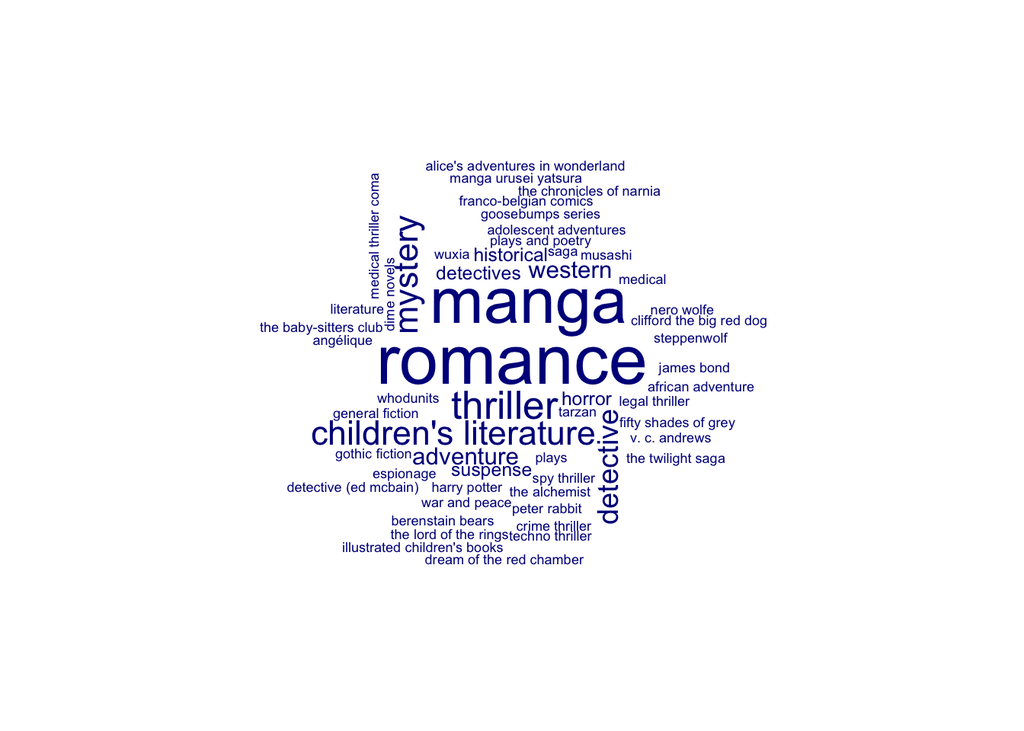

```r
#3.3.1 A wordcloud of different type of fictions

fiction_type <- list(fiction_data_tp[[5]])

dfmfiction <- fiction_type %>%
    tokens() %>%
    dfm()

# try dictionary to show the total number of mystery novels in the macro sense
fiction_data_dictionary <- dictionary(list(Mystery = c("detective","mystery","crime", "Detectives","Crime thriller")))
fiction_dictionary <- dfm_lookup(dfmfiction, fiction_data_dictionary,
                               valuetype = "regex")

#draw the wordcloud of different type of fictions
textplot_wordcloud(dfmfiction,min.freq = 1)
```

[figure not shown]

```r
##3.3.2 A plot to show different type of fictions published by different language


fiction_data_tp2 <- group_by(fiction_data_tp,`Genre and/or major works`) %>%
  filter(length(`Genre and/or major works`)>1) %>%
  filter(`Genre and/or major works` != "Historical")

# Creating the plot
ggplot(fiction_data_tp2) +
  aes(x = `Genre and/or major works`, y = Mean_estimated_sales) +
  geom_col(aes(fill = `Original language`))+
  scale_fill_discrete_sequential(palette = "YlGnBu")+
  coord_cartesian(ylim=c(0,1500))+
  scale_y_continuous("Mean estimatied sales")+
  ggtitle("Best-selling fictions'authors Style Preference",
          subtitle ="Published by Different Languages")+
  theme(plot.title = element_text(hjust = 1,
                                  family = "Times",
                                  face = "bold",
                                  vjust = 1),
        plot.subtitle = element_text(hjust = 1,
                                     family = "Times",
                                     face = "bold",
                                     vjust = 1.5)) +
  theme_minimal()+
  theme(axis.text.x = element_text(size = 8, hjust = 0.9, angle = 45))
```